# pyplot

## Définition

**Pyplot** est un sous module de matplotlib contenant la plupart des utilitaires (fonctions) dont la librairie matplotlib a besoin pour :

- **la création de figures**
- **la création de zones de traçage dans une figure**
- **tracer certaines lignes dans une zone de traçage**
- **décorer des tracés avec des étiquettes, etc.**

Ces utilitaires sont généralement importés sous l'aléas plt.

Avec pyplot, nous pouvons effectuer des tracés de ligne, histogramme, Scatter, tracé 3D, image, contour, etc.

## Installation

Pour utiliser **pyplot**, nous devons d'abord télécharger la librairie **Matplotlib** de la manière suivante :

pip install matplotlib

Nous pouvons maintenant importer la bibliothèque matplotlib pour utiliser son module pyplot.

```python
import matplotlib.pyplot as plt
```

### Quelques fonctions de pyplot

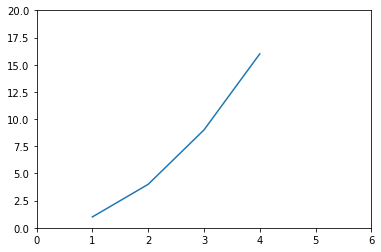

```python
# Programme python pour montrer les fonctions de pyplot
plt.plot([1, 2, 3, 4], [1, 4, 9, 16])
plt.axis([0, 6, 0, 20])
plt.show()
```

- **plot(x, y) :** tracez x et y en utilisant le style de ligne et la couleur par défaut.
- **plot.axis([xmin, xmax, ymin, ymax])**
- **plot(x, y, color='green', marker='o', linestyle='dashed', linewidth=2, markersize=12, label='La légende de la courbe')**
- **plot.xlabel()**
- **plot.ylabel()**

### Exemple1 : Tracé linéaire

### Ecrivons un programme qui nous permet de visualiser l'évolution de la consommation d'électricité : Cas de la Cote d'Ivoire et du Burkina.

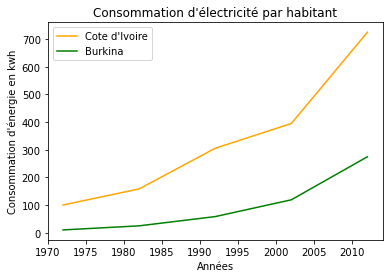

```python
annee = [1972, 1982, 1992, 2002, 2012]
e_cote_ivoire = [100.6, 158.61, 305.54, 394.96, 724.79]
e_burkina = [10.5, 25.21, 58.65, 119.27, 274.87]


plt.plot(annee, e_cote_ivoire, color ='orange',
         label ="Cote d'Ivoire")

plt.plot(annee, e_burkina, color ='g',
         label ='Burkina')

# Noms des axes
plt.xlabel('Années')
plt.ylabel("Consommation d'énergie en kwh")

# Titre
plt.title("Consommation d'électricité par habitant")

plt.legend()
plt.show()
```

### Exemple 2 : Tracé linéaire avec mise en forme des lignes.

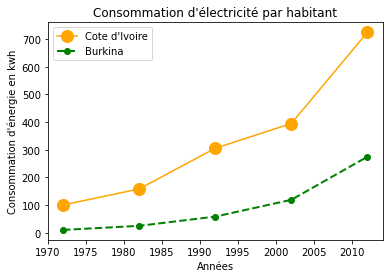

```python
annee = [1972, 1982, 1992, 2002, 2012]
e_cote_ivoire = [100.6, 158.61, 305.54, 394.96, 724.79]
e_burkina = [10.5, 25.21, 58.65, 119.27, 274.87]


plt.plot(annee, e_cote_ivoire, color ='orange',
         label ="Cote d'Ivoire", marker='o', markersize=12)
plt.plot(annee, e_burkina, color ='g', marker='o', markersize=6, linestyle ='dashed', linewidth = 2, label ='Burkina')

# Noms des axes
plt.xlabel('Années')
plt.ylabel("Consommation d'énergie en kwh")

# Titre
plt.title("Consommation d'électricité par habitant")

plt.legend()
plt.show()
```